# Sales_Analysis

Devansh

28/10/2021

# Importing Necessary Libraries

```r
library(data.table)
library(dplyr)
```

```r
library(ggplot2)
library(corrplot)
library(xgboost)
library(cowplot)
library(knitr)
library(caret)
library(moments)
```

# Reading Datasets

```r
train_dataset <- fread("train_dataset.csv")
test_dataset <- fread("test_dataset.csv")
```

# Basic Details about Training Dataset

## Dimension of Training Dataset

```r
dim(train_dataset)
```

```
## [1] 8523   12
```

## Column Names of Training Dataset

```r
names(train_dataset)
```

```
##  [1] "Item_Identifier"           "Item_Weight"
##  [3] "Item_Fat_Content"          "Item_Visibility"
##  [5] "Item_Type"                 "Item_MRP"
##  [7] "Outlet_Identifier"         "Outlet_Establishment_Year"
##  [9] "Outlet_Size"               "Outlet_Location_Type"
## [11] "Outlet_Type"               "Item_Outlet_Sales"
```

## Structure of Training Dataset

```r
str(train_dataset)
```

```
## Classes 'data.table' and 'data.frame':   8523 obs. of  12 variables:
##  $ Item_Identifier          : chr  "FDA15" "DRC01" "FDN15" "FDX07" ...
##  $ Item_Weight              : num  9.3 5.92 17.5 19.2 8.93 ...
##  $ Item_Fat_Content         : chr  "Low Fat" "Regular" "Low Fat" "Regular" ...
##  $ Item_Visibility          : num  0.016 0.0193 0.0168 0 0 ...
##  $ Item_Type                : chr  "Dairy" "Soft Drinks" "Meat" "Fruits and Vegetables" ...
##  $ Item_MRP                 : num  249.8 48.3 141.6 182.1 53.9 ...
##  $ Outlet_Identifier        : chr  "OUT049" "OUT018" "OUT049" "OUT010" ...
##  $ Outlet_Establishment_Year: int  1999 2009 1999 1998 1987 2009 1987 1985 2002 2007 ...
##  $ Outlet_Size              : chr  "Medium" "Medium" "Medium" "" ...
##  $ Outlet_Location_Type     : chr  "Tier 1" "Tier 3" "Tier 1" "Tier 3" ...
##  $ Outlet_Type              : chr  "Supermarket Type1" "Supermarket Type2" "Supermarket Type1" "Grocery Store" ...
##  $ Item_Outlet_Sales        : num  3735 443 2097 732 995 ...
##  - attr(*, ".internal.selfref")=<externalptr>
```

# Basic Details about Testing Dataset

## Dimension of Testing Dataset

```r
dim(test_dataset)
```

```
## [1] 5681   11
```

## Column Names of Testing Dataset

```r
names(test_dataset)
```

```
##  [1] "Item_Identifier"           "Item_Weight"
##  [3] "Item_Fat_Content"          "Item_Visibility"
##  [5] "Item_Type"                 "Item_MRP"
##  [7] "Outlet_Identifier"         "Outlet_Establishment_Year"
##  [9] "Outlet_Size"               "Outlet_Location_Type"
## [11] "Outlet_Type"
```

## Structure of Testing Dataset

```r
str(test_dataset)
```

```
## Classes 'data.table' and 'data.frame':   5681 obs. of  11 variables:
##  $ Item_Identifier          : chr  "FDW58" "FDW14" "NCN55" "FDQ58" ...
##  $ Item_Weight              : num  20.75 8.3 14.6 7.32 NA ...
##  $ Item_Fat_Content         : chr  "Low Fat" "reg" "Low Fat" "Low Fat" ...
##  $ Item_Visibility          : num  0.00756 0.03843 0.09957 0.01539 0.1186 ...
##  $ Item_Type                : chr  "Snack Foods" "Dairy" "Others" "Snack Foods" ...
##  $ Item_MRP                 : num  107.9 87.3 241.8 155 234.2 ...
##  $ Outlet_Identifier        : chr  "OUT049" "OUT017" "OUT010" "OUT017" ...
##  $ Outlet_Establishment_Year: int  1999 2007 1998 2007 1985 1997 2009 1985 2002 2007 ...
##  $ Outlet_Size              : chr  "Medium" "" "" "" ...
##  $ Outlet_Location_Type     : chr  "Tier 1" "Tier 2" "Tier 3" "Tier 2" ...
##  $ Outlet_Type              : chr  "Supermarket Type1" "Supermarket Type1" "Grocery Store" "Supermarket Type1" ...
##  - attr(*, ".internal.selfref")=<externalptr>
```

```r
head(test_dataset)
```

```
##    Item_Identifier Item_Weight Item_Fat_Content Item_Visibility
## 1:           FDW58      20.750          Low Fat     0.007564836
## 2:           FDW14       8.300              reg     0.038427677
## 3:           NCN55      14.600          Low Fat     0.099574908
## 4:           FDQ58       7.315          Low Fat     0.015388393
## 5:           FDY38          NA          Regular     0.118599314
## 6:           FDH56       9.800          Regular     0.063817206
##                Item_Type Item_MRP Outlet_Identifier Outlet_Establishment_Year
## 1:           Snack Foods 107.8622            OUT049                      1999
## 2:                 Dairy  87.3198            OUT017                      2007
## 3:                Others 241.7538            OUT010                      1998
## 4:           Snack Foods 155.0340            OUT017                      2007
## 5:                 Dairy 234.2300            OUT027                      1985
## 6: Fruits and Vegetables 117.1492            OUT046                      1997
##    Outlet_Size Outlet_Location_Type       Outlet_Type
## 1:      Medium               Tier 1 Supermarket Type1
## 2:                           Tier 2 Supermarket Type1
## 3:                           Tier 3     Grocery Store
## 4:                           Tier 2 Supermarket Type1
## 5:      Medium               Tier 3 Supermarket Type3
## 6:       Small               Tier 1 Supermarket Type1
```

```r
test_dataset[,Item_Outlet_Sales := NA]
merged = rbind(train_dataset, test_dataset)
dim(merged)
```

```
## [1] 14204    12
```

# Continuous Data

## Item_Outlet_Sales is Dependent Variable

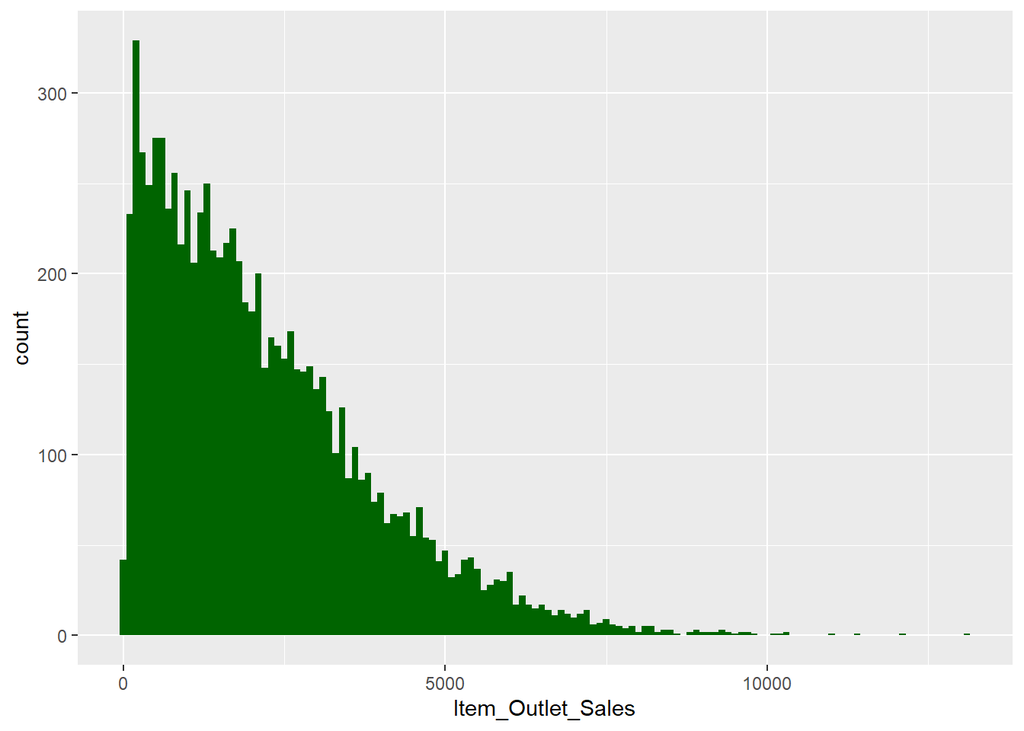

```r
ggplot(train_dataset) + geom_histogram(aes(train_dataset$Item_Outlet_Sales), binwidth = 100, fill = "darkgreen") +
  xlab("Item_Outlet_Sales")
```

**Insight - Data here is Right Skewed**

## Item_Weight, Item_Visibility, Item_MRP are Independent Variables

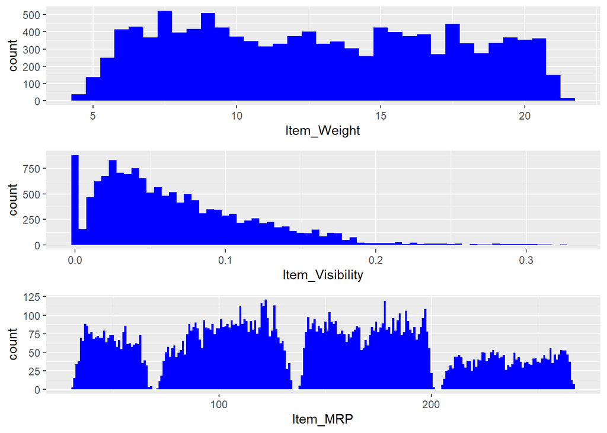

```r
p1 = ggplot(merged) + geom_histogram(aes(Item_Weight), binwidth = 0.5, fill = "blue")
p2 = ggplot(merged) + geom_histogram(aes(Item_Visibility), binwidth = 0.005, fill = "blue")
p3 = ggplot(merged) + geom_histogram(aes(Item_MRP), binwidth = 1, fill = "blue")
plot_grid(p1, p2, p3, ncol = 1) # plot_grid() from cowplot package
```

**Insights -** + No Pattern in Item_Weight + Item_Visibility is Right Skewed + Item_MRP has 4 sections

# Categorical Data

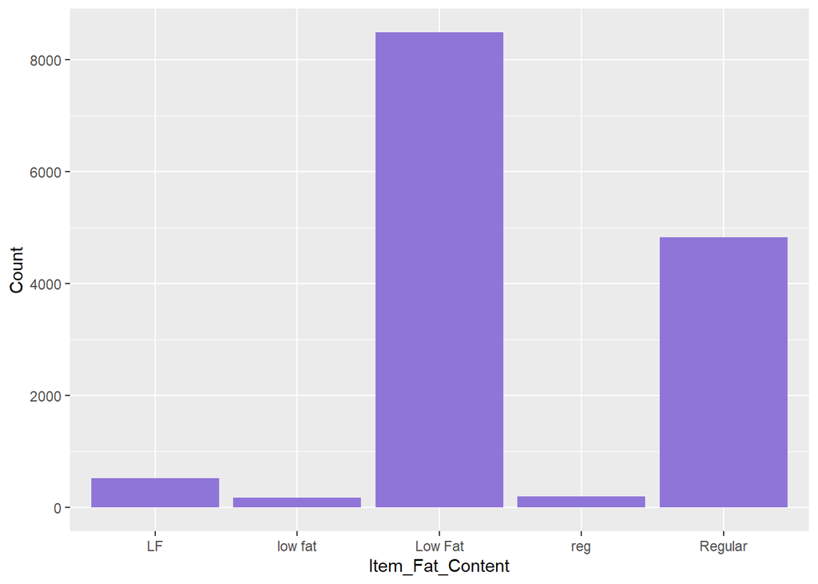

```r
ggplot(merged %>% group_by(Item_Fat_Content) %>% summarise(Count = n())) +
  geom_bar(aes(Item_Fat_Content, Count), stat = "identity", fill = "#9075D8")
```

**Here LF, low fat, Low Fat refers to single Entity only, so they should be renamed to Low Fat to remove redundancy and same goes for reg and Regular**

```r
merged$Item_Fat_Content[merged$Item_Fat_Content == "low fat"] <- "Low Fat"
merged$Item_Fat_Content[merged$Item_Fat_Content == "LF"] <- "Low Fat"
merged$Item_Fat_Content[merged$Item_Fat_Content == "reg"] <- "Regular"
```

**Updated Graph**

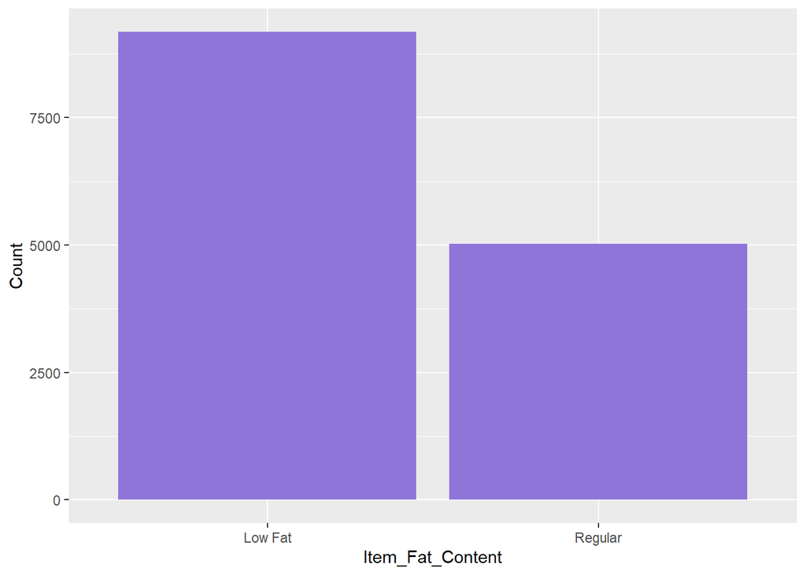

```r
ggplot(merged %>% group_by(Item_Fat_Content) %>% summarise(Count = n())) +
  geom_bar(aes(Item_Fat_Content, Count), stat = "identity", fill = "#9075D8")
```

**Insight - Low Fat has more counts than Regular**

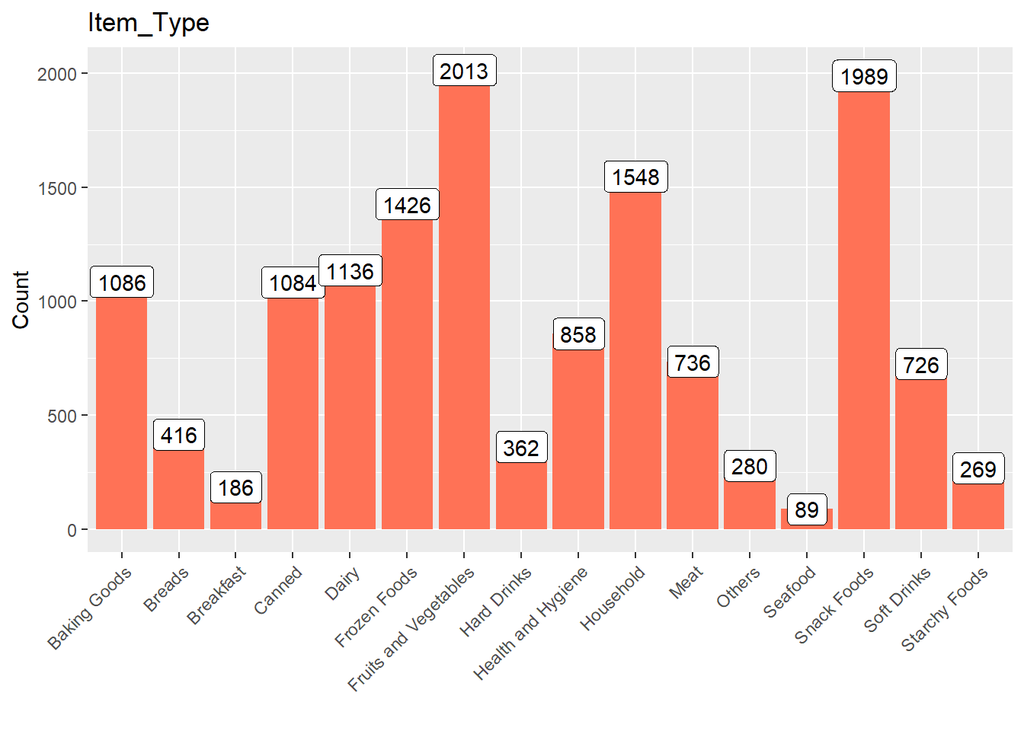

```r
ggplot(merged %>% group_by(Item_Type) %>% summarise(Count = n())) +
  geom_bar(aes(Item_Type, Count), stat = "identity", fill = "coral1") +
  xlab("") +
  geom_label(aes(Item_Type, Count, label = Count), vjust = 0.5) +
  theme(axis.text.x = element_text(angle = 45, hjust = 1))+
  ggtitle("Item_Type")
```

**Insight - Fruits and Vegetables are biggest sellers while Seafood is the least**

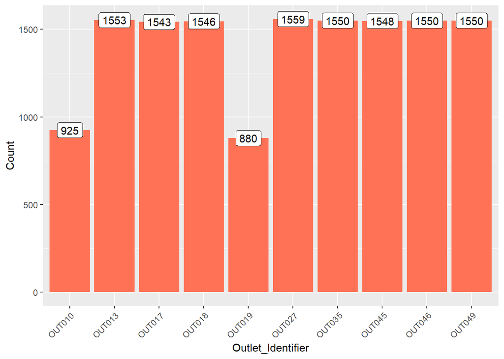

```r
ggplot(merged %>% group_by(Outlet_Identifier) %>% summarise(Count = n())) +
  geom_bar(aes(Outlet_Identifier, Count), stat = "identity", fill = "coral1") +
  geom_label(aes(Outlet_Identifier, Count, label = Count), vjust = 0.5) +
  theme(axis.text.x = element_text(angle = 45, hjust = 1))
```

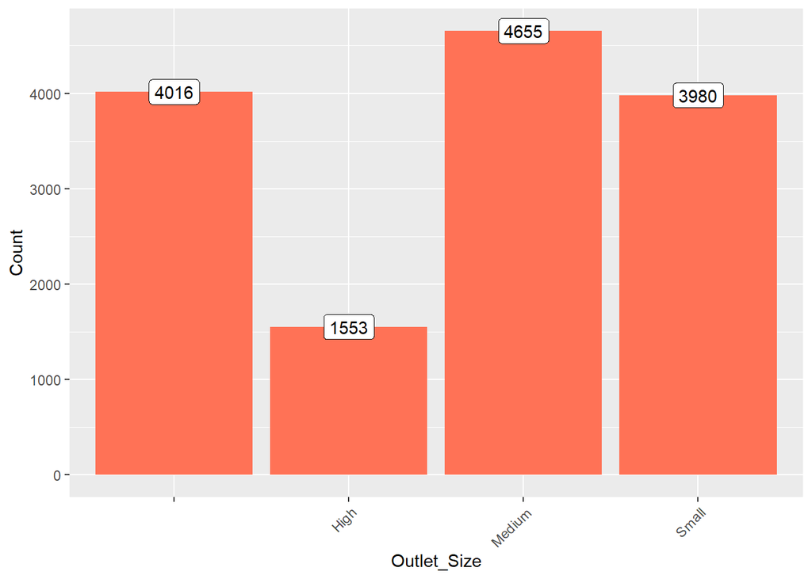

```r
ggplot(merged %>% group_by(Outlet_Size) %>% summarise(Count = n())) +
  geom_bar(aes(Outlet_Size, Count), stat = "identity", fill = "coral1") +
  geom_label(aes(Outlet_Size, Count, label = Count), vjust = 0.5) +
  theme(axis.text.x = element_text(angle = 45, hjust = 1))
```

**Insight - 4016 outlets don’t have a outlet size**

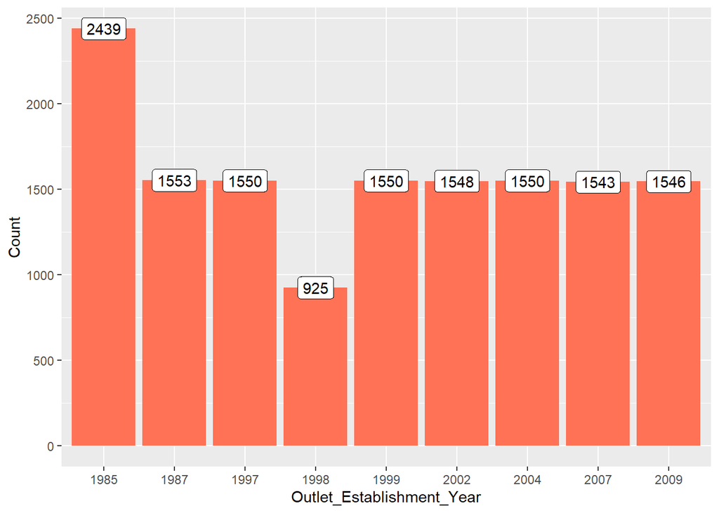

```r
ggplot(merged %>% group_by(Outlet_Establishment_Year) %>% summarise(Count = n())) +
  geom_bar(aes(factor(Outlet_Establishment_Year), Count), stat = "identity", fill = "coral1") +
  geom_label(aes(factor(Outlet_Establishment_Year), Count, label = Count), vjust = 0.5) +
  xlab("Outlet_Establishment_Year") +
  theme(axis.text.x = element_text(size = 8.5))
```

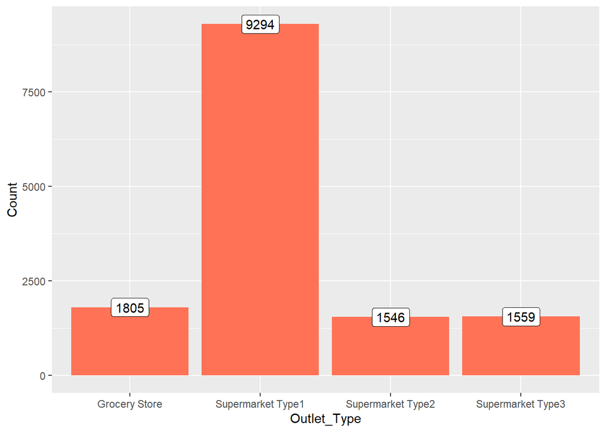

```r
ggplot(merged %>% group_by(Outlet_Type) %>% summarise(Count = n())) +
  geom_bar(aes(Outlet_Type, Count), stat = "identity", fill = "coral1") +
  geom_label(aes(factor(Outlet_Type), Count, label = Count), vjust = 0.5) +
  theme(axis.text.x = element_text(size = 8.5))
```

**Insight - Type 1 Supermarket is has the popular Outlet Type**

# Bivarite Analysis

Updating the Training Dataset

```r
train_dataset = merged[1:nrow(train_dataset)]
```

## Continuous Variables

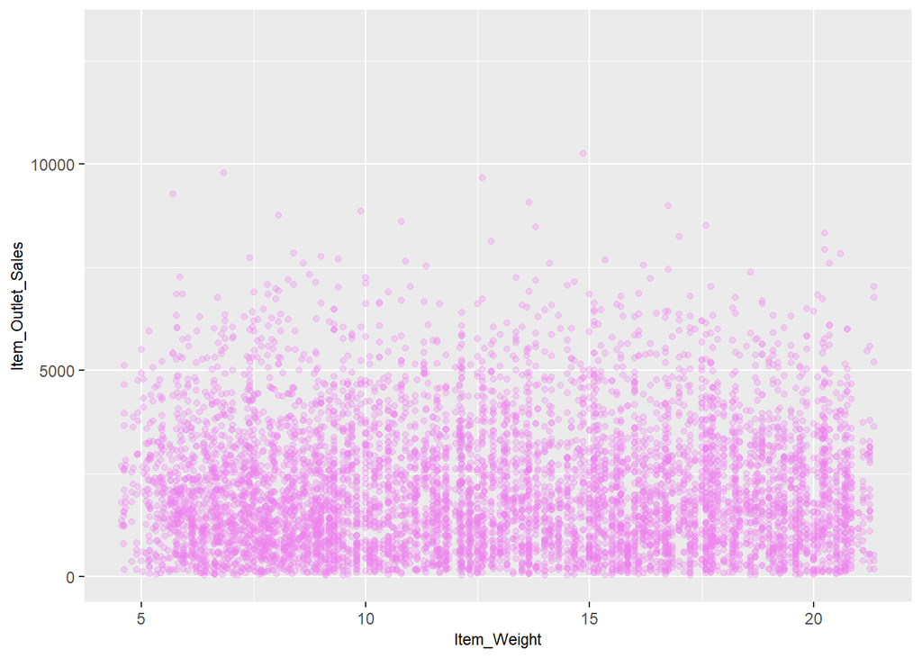

```r
ggplot(train_dataset) + geom_point(aes(Item_Weight, Item_Outlet_Sales), colour = "violet", alpha = 0.3) +
     theme(axis.title = element_text(size = 8.5))
```

**Insight - Item_Outlet_Sales is spread well across the entire range of the Item_Weight without any obvious pattern.**

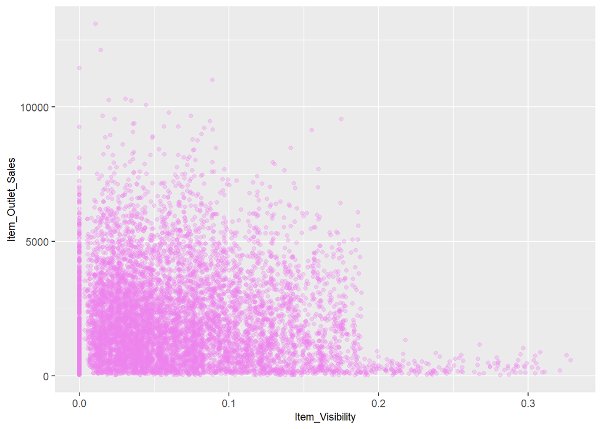

```r
ggplot(train_dataset) + geom_point(aes(Item_Visibility, Item_Outlet_Sales), colour = "violet", alpha = 0.3) +
     theme(axis.title = element_text(size = 8.5))
```

**Insight - In the Item_Visibility vs Item_Outlet_Sales, there is a string of points at Item_Visibility = 0.0 which seems strange as item visibility cannot be completely zero. We will take note of this issue and deal with it in the later stages.**

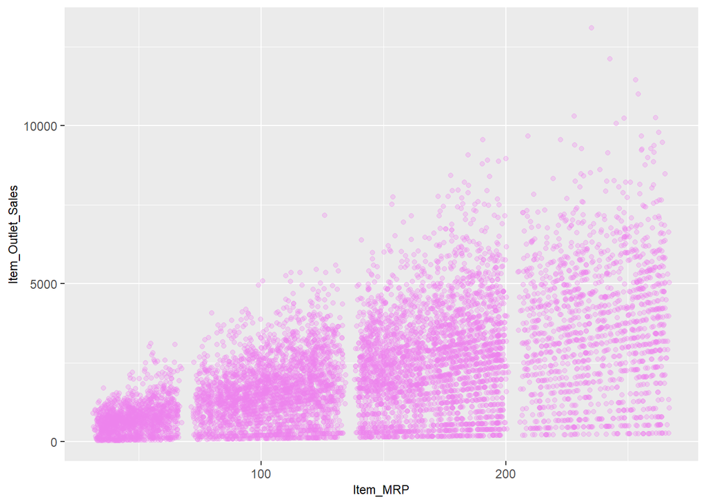

```r
ggplot(train_dataset) + geom_point(aes(Item_MRP, Item_Outlet_Sales), colour = "violet", alpha = 0.3) +
     theme(axis.title = element_text(size = 8.5))
```

**Insight - In Item_MRP vs Item_Outlet_Sales, we can clearly see 4 segments of prices that can be used in feature engineering to create a new variable.**

## Categorical Variables

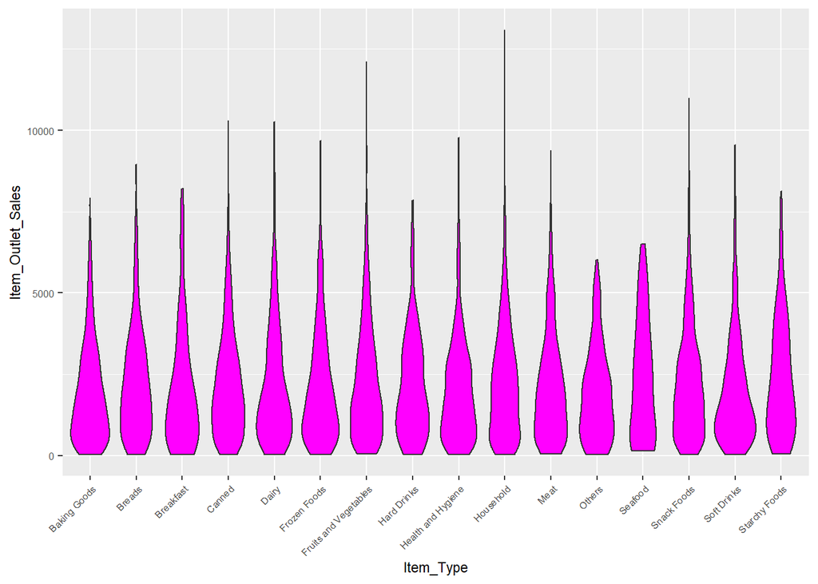

```r
ggplot(train_dataset) + geom_violin(aes(Item_Type, Item_Outlet_Sales), fill = "magenta") +
  theme(axis.text.x = element_text(angle = 45, hjust = 1),
        axis.text = element_text(size = 6),
        axis.title = element_text(size = 8.5))
```

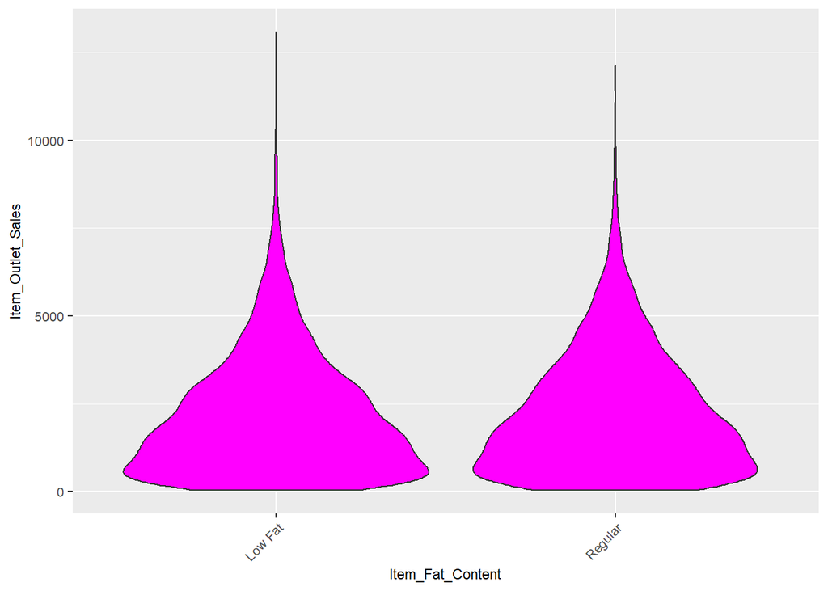

```r
ggplot(train_dataset) + geom_violin(aes(Item_Fat_Content, Item_Outlet_Sales), fill = "magenta") +
  theme(axis.text.x = element_text(angle = 45, hjust = 1),
        axis.text = element_text(size = 8),
        axis.title = element_text(size = 8.5))
```

**Insight - Distribution of Item_Outlet_Sales across the categories of Item_Type is not very distinct and same is the case with Item_Fat_Content.**

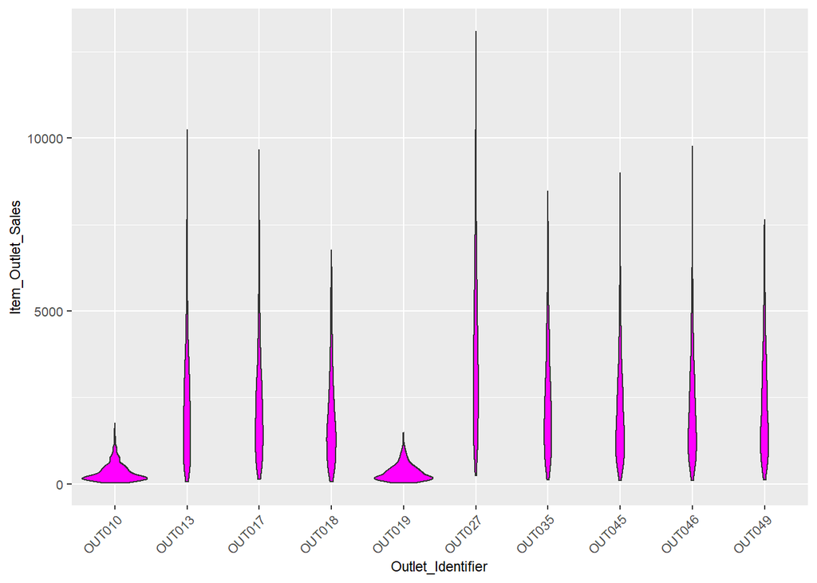

```r
ggplot(train_dataset) + geom_violin(aes(Outlet_Identifier, Item_Outlet_Sales), fill = "magenta") +
  theme(axis.text.x = element_text(angle = 45, hjust = 1),
        axis.text = element_text(size = 8),
        axis.title = element_text(size = 8.5))
```

**Insight - The distribution for OUT010 and OUT019 categories of Outlet_Identifier are quite similar and very much different from the rest of the categories of Outlet_Identifier.**

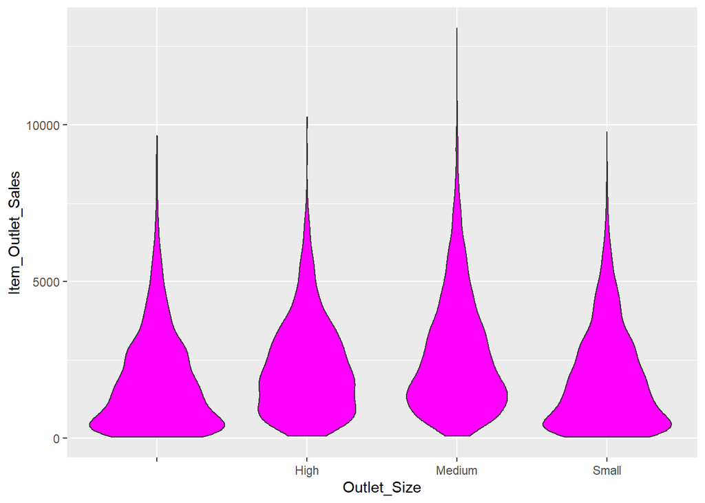

```r
ggplot(train_dataset) + geom_violin(aes(Outlet_Size, Item_Outlet_Sales), fill = "magenta")
```

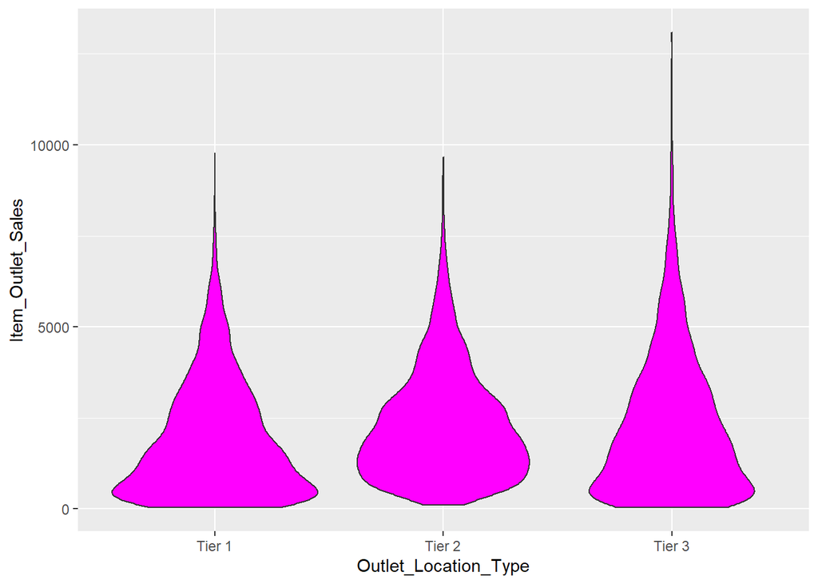

```r
ggplot(train_dataset) + geom_violin(aes(Outlet_Location_Type, Item_Outlet_Sales), fill = "magenta")
```

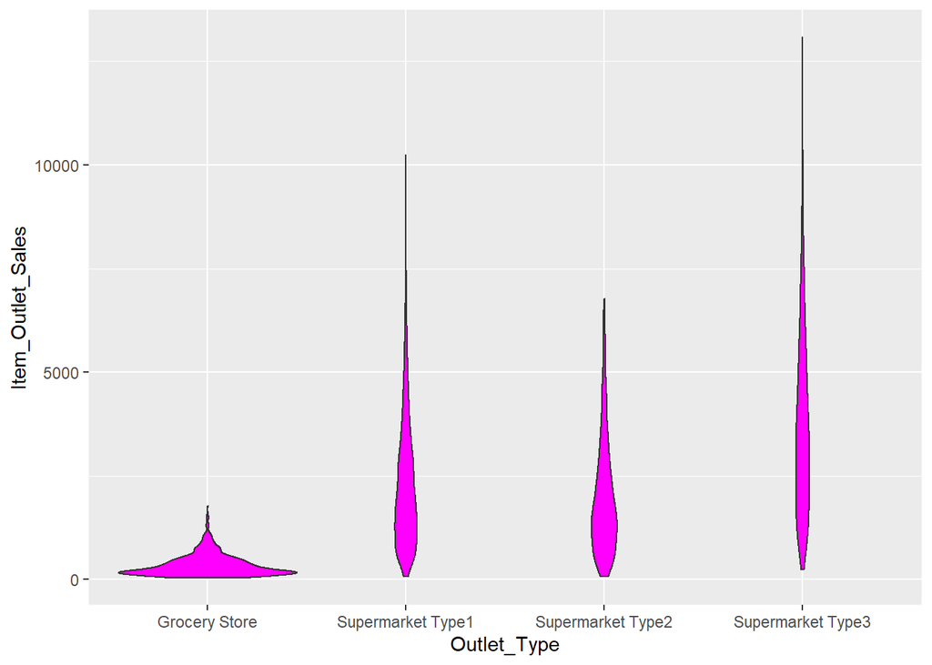

```r
ggplot(train_dataset) + geom_violin(aes(Outlet_Type, Item_Outlet_Sales), fill = "magenta")
```

# Missing Value Treatment

```r
colSums(is.na(merged))
```

```
##           Item_Identifier               Item_Weight          Item_Fat_Content
##                         0                      2439                         0
##           Item_Visibility                 Item_Type                  Item_MRP
##                         0                         0                         0
##         Outlet_Identifier Outlet_Establishment_Year               Outlet_Size
##                         0                         0                         0
##      Outlet_Location_Type               Outlet_Type         Item_Outlet_Sales
##                         0                         0                      5681
```

#### Replacing Null values with mean value in Item_Weight

```r
missing_index = which(is.na(merged$Item_Weight))
for(i in missing_index){

  item = merged$Item_Identifier[i]
  merged$Item_Weight[i] = mean(merged$Item_Weight[merged$Item_Identifier == item], na.rm = T)

}
```

#### Replacing 0’s in Item_Visibility variable

```r
zero_index = which(merged$Item_Visibility == 0)
for(i in zero_index){

  item = merged$Item_Identifier[i]
  merged$Item_Visibility[i] = mean(merged$Item_Visibility[merged$Item_Identifier == item], na.rm = T)

}
```

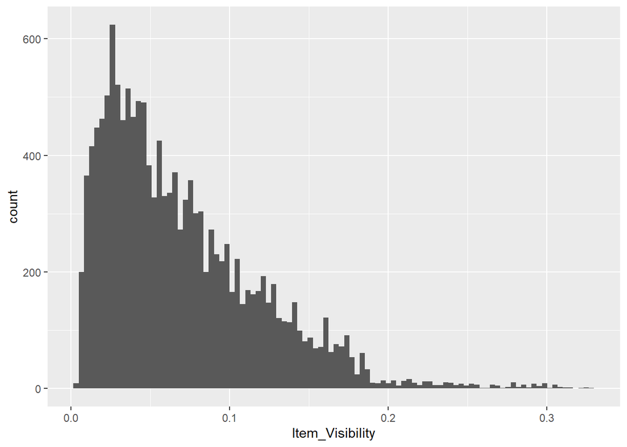

```r
ggplot(merged) + geom_histogram(aes(Item_Visibility), bins=100)
```

```r
table(train_dataset$Outlet_Size)
```

```
##
##          High Medium  Small
##   2410    932   2793   2388
```

**Since Medium value is has the most frequency so replacing blank strings with medium**

```r
train_dataset$Outlet_Size[train_dataset$Outlet_Size==""]<-"Medium"
```

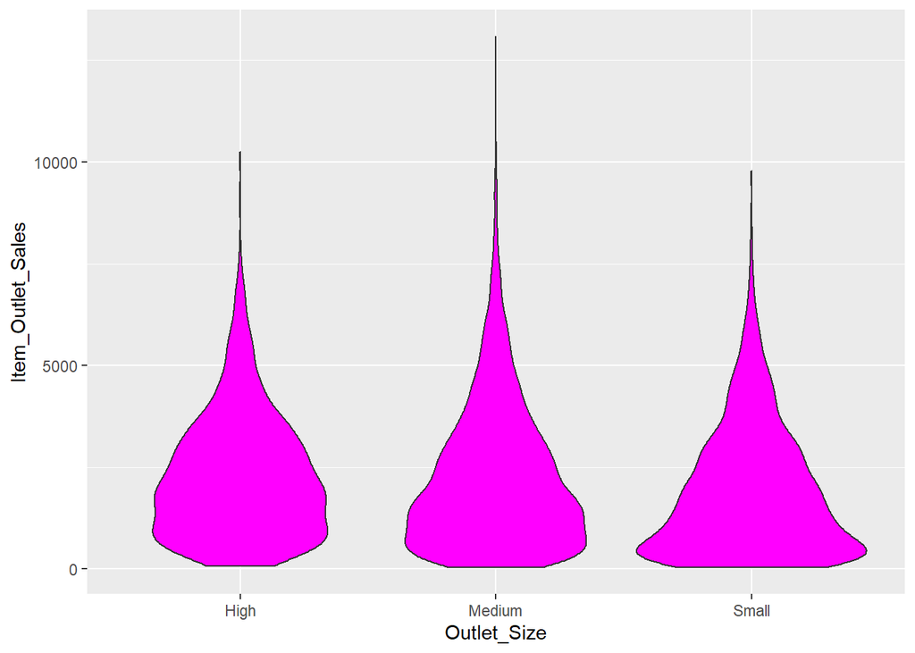

```r
ggplot(train_dataset) + geom_violin(aes(Outlet_Size, Item_Outlet_Sales), fill = "magenta")
```

# Feature Engineering

- Item_Type_new: Broader categories for the variable Item_Type.
- Item_category: Categorical variable derived from Item_Identifier.
- Outlet_Years: Years of operation for outlets.
- price_per_unit_wt: Item_MRP/Item_Weight
- Item_MRP_clusters: Binned feature for Item_MRP.

```r
table(merged$Item_Type)
```

```
##
##          Baking Goods                Breads             Breakfast
##                  1086                   416                   186
##                Canned                 Dairy          Frozen Foods
##                  1084                  1136                  1426
## Fruits and Vegetables           Hard Drinks    Health and Hygiene
##                  2013                   362                   858
##             Household                  Meat                Others
##                  1548                   736                   280
##               Seafood           Snack Foods           Soft Drinks
##                    89                  1989                   726
##         Starchy Foods
##                   269
```

```r
perishable = c("Breads", "Breakfast", "Dairy", "Fruits and Vegetables", "Meat", "Seafood")
non_perishable = c("Baking Goods", "Canned", "Frozen Foods", "Hard Drinks", "Health and Hygiene",
                   "Household", "Soft Drinks")
merged[,Item_Type_new := ifelse(Item_Type %in% perishable, "perishable",
                               ifelse(Item_Type %in% non_perishable, "non_perishable", "not_sure"))]
```

```r
merged[,Item_category := substr(merged$Item_Identifier, 1, 2)]
merged$Item_Fat_Content[merged$Item_category == "NC"] = "Non-Edible"
```

```r
merged[,Outlet_Years := 2013 - Outlet_Establishment_Year]
merged$Outlet_Establishment_Year = as.factor(merged$Outlet_Establishment_Year)
```

```r
# Price per unit weight
merged[,price_per_unit_wt := Item_MRP/Item_Weight]
```

Earlier in the Item_MRP vs Item_Outlet_Sales plot, we saw Item_MRP was spread across in 4 chunks. We can use k Means clustering to create 4 groups using Item_MRP variable.

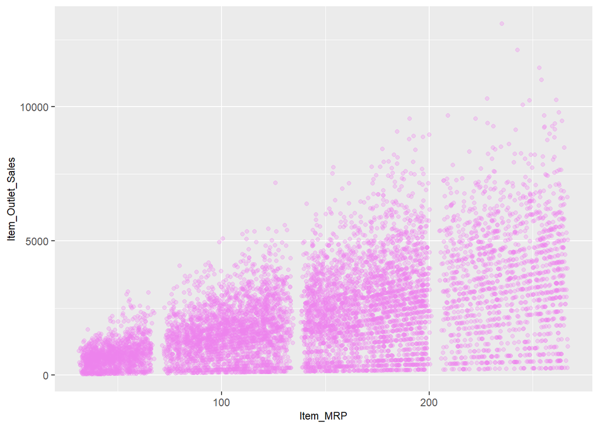

```r
ggplot(train_dataset) + geom_point(aes(Item_MRP, Item_Outlet_Sales), colour = "violet", alpha = 0.3) +
     theme(axis.title = element_text(size = 8.5))
```

```r
Item_MRP_clusters = kmeans(merged$Item_MRP, centers = 4)
table(Item_MRP_clusters$cluster)
```

```
##
##    1    2    3    4
## 2400 4931 4317 2556
```

```r
merged$Item_MRP_clusters = as.factor(Item_MRP_clusters$cluster)
```

# Encoding Categorical Variables

In this stage, we will convert our categorical variables into numerical ones. We will use 2 techniques — Label Encoding and One Hot Encoding.

- **Label encoding** simply means converting each category in a variable to a number. It is more suitable for ordinal variables — categorical variables with some order.
- In **One hot encoding**, each category of a categorical variable is converted into a new bunary column (1/0).

### Label encoding for the categorical variables

We will label encode Outlet_Size and Outlet_Location_Type as these are ordinal variables.

```r
merged[,Outlet_Size_num := ifelse(Outlet_Size == "Small", 0,
                                 ifelse(Outlet_Size == "Medium", 1, 2))]
merged[,Outlet_Location_Type_num := ifelse(Outlet_Location_Type == "Tier 3", 0,
                                          ifelse(Outlet_Location_Type == "Tier 2", 1, 2))]
# removing categorical variables after label encoding
merged[, c("Outlet_Size", "Outlet_Location_Type") := NULL]
```

```r
ohe = dummyVars("~.", data = merged[,-c("Item_Identifier", "Outlet_Establishment_Year", "Item_Type")], fullRank = T)
ohe_df = data.table(predict(ohe, merged[,-c("Item_Identifier", "Outlet_Establishment_Year", "Item_Type")]))
merged = cbind(merged[,"Item_Identifier"], ohe_df)
```

# Pre Processing Data

### Checking Skewness

Skewness in variables is undesirable for predictive modeling. Some machine learning methods assume normally distributed data and a skewed variable can be transformed by taking its log, square root, or cube root so as to make the distribution of the skewed variable as close to normal distribution as possible.

```r
skewness(merged$Item_Visibility)
```

```
## [1] 1.254178
```

```r
skewness(merged$price_per_unit_wt)
```

```
## [1] 1.304689
```

```r
merged[,Item_Visibility := log(Item_Visibility + 1)] # log + 1 to avoid division by zero
merged[,price_per_unit_wt := log(price_per_unit_wt + 1)]
```

```r
num_vars = which(sapply(merged, is.numeric)) # index of numeric features
num_vars_names = names(num_vars)
combi_numeric = merged[,setdiff(num_vars_names, "Item_Outlet_Sales"), with = F]
prep_num = preProcess(combi_numeric, method=c("center", "scale"))
combi_numeric_norm = predict(prep_num, combi_numeric)
```

```r
merged[,setdiff(num_vars_names, "Item_Outlet_Sales") := NULL] # removing numeric independent variables
merged = cbind(merged, combi_numeric_norm)
```

```r
train_dataset = merged[1:nrow(train_dataset)]
test_dataset = merged[(nrow(train_dataset) + 1):nrow(merged)]
test_dataset[,Item_Outlet_Sales := NULL] # removing Item_Outlet_Sales as it contains only NA
```

# Correlated Variables

- negative correlation: < 0 and >= -1
- positive correlation: > 0 and <= 1
- no correlation: 0 It is not desirable to have correlated features if we are using linear regressions.

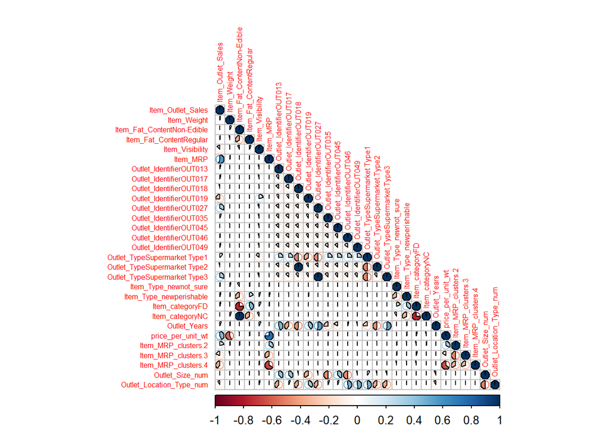

```r
cor_train = cor(train_dataset[,-c("Item_Identifier")])
corrplot(cor_train, method = "pie", type = "lower", tl.cex = 0.5, number.cex=0.75)
```

# Modeling

## Linear Regression

```r
linear_reg_mod = lm(Item_Outlet_Sales ~ ., data = train_dataset[,-c("Item_Identifier")])
```

```r
set.seed(1234)
my_control = trainControl(method="cv", number=5)
linear_reg_mod = train(x = train_dataset[,-c("Item_Identifier", "Item_Outlet_Sales")], y = train_dataset$Item_Outlet_Sales,
                       method='glmnet', trControl= my_control)
```

```r
print(round(linear_reg_mod$resample$RMSE, 2))
```

```
## [1] 1127.82 1119.80 1148.71 1122.18 1132.36
```

## Lasso Regression

```r
set.seed(1235)
my_control = trainControl(method="cv", number=5)
Grid = expand.grid(alpha = 1, lambda = seq(0.001,0.1,by = 0.0002))

lasso_linear_reg_mod = train(x = train_dataset[, -c("Item_Identifier", "Item_Outlet_Sales")], y = train_dataset$Item_Outlet_Sales,
                       method='glmnet', trControl= my_control, tuneGrid = Grid)
```

```r
print(round(lasso_linear_reg_mod$resample$RMSE, 2))
```

```
## [1] 1115.43 1117.70 1170.87 1117.42 1126.26
```

## Ridge Regression

```r
set.seed(1236)
my_control = trainControl(method="cv", number=5)
Grid = expand.grid(alpha = 0, lambda = seq(0.001,0.1,by = 0.0002))

ridge_linear_reg_mod = train(x = train_dataset[, -c("Item_Identifier", "Item_Outlet_Sales")], y = train_dataset$Item_Outlet_Sales,
                       method='glmnet', trControl= my_control, tuneGrid = Grid)
```

```r
print(round(ridge_linear_reg_mod$resample$RMSE, 2))
```

```
## [1] 1125.99 1137.01 1110.43 1152.19 1145.98
```

## Random Forest

```r
set.seed(1237)
my_control = trainControl(method="cv", number=5)

tgrid = expand.grid(
  .mtry = c(3:10),
  .splitrule = "variance",
  .min.node.size = c(10,15,20)
)

rf_mod = train(x = train_dataset[, -c("Item_Identifier", "Item_Outlet_Sales")],
               y = train_dataset$Item_Outlet_Sales,
               method='ranger',
               trControl= my_control,
               tuneGrid = tgrid,
               num.trees = 400,
               importance = "permutation")
```

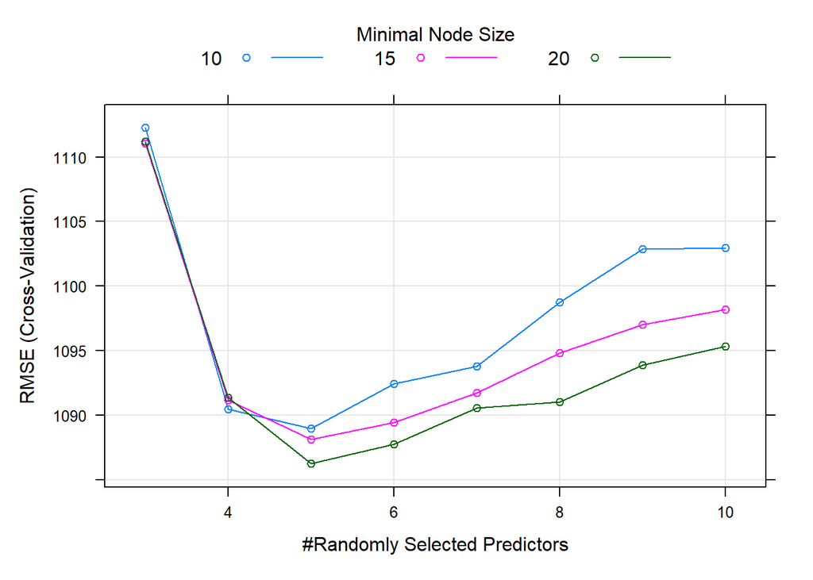

```r
plot(rf_mod)
```

## XGBoost

*eta: It is also known as the learning rate or the shrinkage factor. It actually shrinks the feature weights to make the boosting process more conservative. The range is 0 to 1. Low eta value means model is more robust to overfitting.* gamma: The range is 0 to ∞. Larger the gamma more conservative the algorithm is. *max_depth: We can specify maximum depth of a tree using this parameter.* subsample: It is the proportion of rows that the model will randomly select to grow trees. *colsample_bytree: It is the ratio of variables randomly chosen for build each tree in the model.

```r
param_list = list(
        objective = "reg:linear",
        eta=0.01,
        gamma = 1,
        max_depth=6,
        subsample=0.8,
        colsample_bytree=0.5
        )
```

```r
dtrain = xgb.DMatrix(data = as.matrix(train_dataset[,-c("Item_Identifier", "Item_Outlet_Sales")]), label= train_dataset$Item_Outlet_Sales)
dtest = xgb.DMatrix(data = as.matrix(test_dataset[,-c("Item_Identifier")]))
```

```r
set.seed(112)
xgbcv = xgb.cv(params = param_list,
               data = dtrain,
               nrounds = 1000,
               nfold = 5,
               print_every_n = 10,
               early_stopping_rounds = 30,
               maximize = F)
```

[output not shown]

```r
xgb_model = xgb.train(data = dtrain, params = param_list, nrounds = 430)
```

```
## [23:32:35] WARNING: amalgamation/../src/objective/regression_obj.cu:171: reg:linear is now deprecated in favor of reg:squarederror.
```

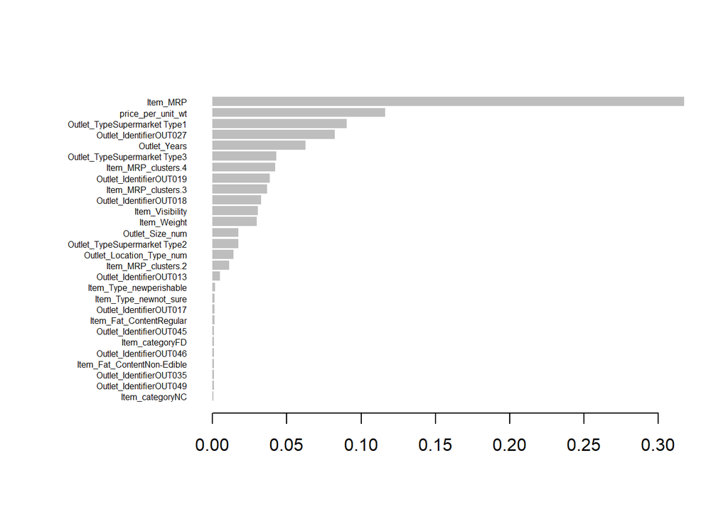

```r
var_imp = xgb.importance(feature_names = setdiff(names(train), c("Item_Identifier", "Item_Outlet_Sales")),
                         model = xgb_model)
xgb.plot.importance(var_imp)
```

**Item_MRP is the most important variable in predicting the target variable. New features created by us, like price_per_unit_wt, Outlet_Years, Item_MRP_Clusters, are also among the top most important variables.**